# Разведочный анализ данных + Подготовка отчётов — Kiva.org¶

# Kiva и её деятельность

Kiva — это некоммерческая организация, которая позволяет нуждающимся более чем в 80 странах мира получать финансирование под различного рода проекты и нужды.

Девиз Kiva — **Make a loan, change a life**.

В основном деятельность Kiva связана с поддержкой населения, развитием малого бизнеса, а также финансированием социальных проектов. Список заявок, назначений и стран, нуждающихся в финансировании, можно посмотреть на сайте kiva.org. Это темы, так или иначе связанные с сельским хозяйством, питанием, здоровьем и гигиеной, розничной торговлей и поддержкой малого бизнеса.

**На сегодняшний день Kiva профинансировала 2 млн заёмщиков на сумму более 1 млрд долларов. Она считается одним из главных участников борьбы с бедностью, особенно во многих африканских странах.**

- За время существования Kiva помогла 2,7 млн нуждающихся.
- 1,7 млн небезразличных участников, желающих помочь.
- 83 страны.
- Сумма средств, финансируемых через Kiva, составляет $1,11 млрд.
- 97,0% — доля возврата средств инвесторам (очень высокий показатель).
- 81% заёмщиков Kiva — женщины.
- Кредит Kiva финансируется каждые 2 минуты.

## Постановка задач и формулирование вопросов

Kiva хочет сделать так, чтобы собранные деньги тратились с максимальной пользой. В первую очередь их интересуют не дисперсия пожертвований и статистические показатели, а ощутимые выводы и рекомендации, которые позволят организации работать эффективнее и лучше понимать специфику потребностей и уровень бедности в разных странах и регионах.

- Проверьте, насколько имеющиеся данные чисты, то есть подвержены выбросам, пропущенным и недействительным значениям.
- Ознакомьтесь с датасетом, изучите его базовые характеристики, выявите первоначальные зависимости.
- Изучите основные демографические характеристики людей, которые используют Kiva. Из каких они регионов и стран? Какова гендерная характеристика заёмщиков?
- Посмотрите, для каких целей людям нужны средства и какие суммы они просят. Изучите сектора экономики, виды деятельности и сделайте выводы о том, как обстоят дела в каждом из них.
- Немаловажным является ещё один вопрос: как долго заёмщикам приходится ждать полного финансирования заявки? Известно, что некоторые люди на платформе просят ссуды на неотложные нужды.
- Попробуйте изучить факторы, влияющие на время, которое потребуется на погашение ссуды и суммы кредита. Возможно, это поможет лучше узнать, сколько люди в конкретных регионах могут себе позволить выплачивать на самые важные нужды.
- Сформулируйте основные выводы и приложите визуальные материалы, подкрепляющие их.

## Набор данных от Kiva

**kiva_loans** — это набор данных, который содержит большую часть информации о займах:

- id — уникальный идентификатор для кредита.
- funded_amount — сумма, выплаченная Kiva агенту на местах (USD).
- loan_amount — сумма, выплаченная полевым агентом заёмщику (USD).
- sector — сектор использования займа.
- activity — более гранулированная категория.
- use — назначение использования суммы кредита.
- country_code — ISO-код страны страны, в которой был выдан заём.
- country — полное название страны, в которой был выдан кредит.
- posted_time — время, в которое заявка была опубликована на Kiva.
- disbursed_time — время, когда кредитный агент выдал заёмщику сумму.
- funded_time — время, когда заявка полностью финансируется кредиторами.
- term_in_months — срок, на который был выдан кредит в месяцах.
- lender_count — общее количество кредиторов, которые внесли свой вклад в этот кредит.
- loaner_genders — разделённые запятыми буквы M, F, где каждый экземпляр представляет одного мужчину/женщину в группе.

**kiva_mpi_region_locations** — Набор данных о регионах с показателями MPI: (Global Multidimensional Poverty Index — глобальный индекс бедности) ряда регионов (субнациональных) в мире. Чем больше это значение, тем выше уровень бедности в соответствующем регионе.

- country — страна.
- region — регион в стране.
- world_region — часть света.
- MPI — многомерный индекс бедности.
- geo — координаты (широта, долгота).

# Разведочный анализ данных

```python
import numpy as np
import pandas as pd
import math
import missingno as msno
from datetime import datetime, timedelta

import matplotlib.pyplot as plt
%matplotlib inline
import seaborn as sns
plt.style.use('seaborn-darkgrid')
palette = plt.get_cmap('Set2')

import os
```

```python
df_kiva_loans = pd.read_csv("./kiva_loans.csv")
df_mpi = pd.read_csv("./kiva_mpi_region_locations.csv")
```

**Вывод первых строк датасета:**

```python
df_kiva_loans.head(5)
```

[output not shown]

**Проверка на наличие пропущенных значений**.

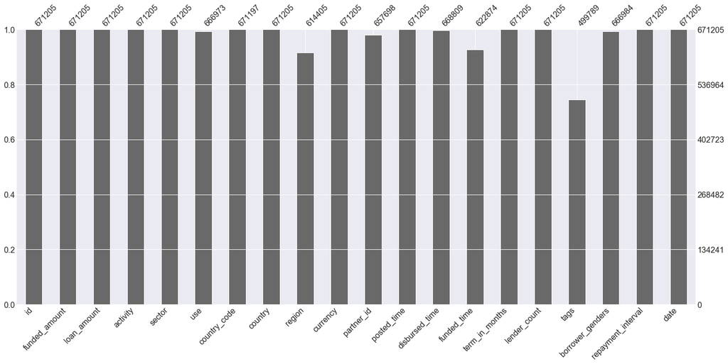

```python
msno.bar(df_kiva_loans) #процентное содержание пропущенных значений по каждой из колонок
```

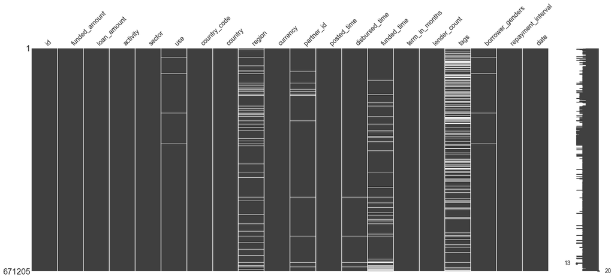

```python
msno.matrix(df_kiva_loans)
#структурное содержание пропущенных значений, т.е. их распределение внутри датасэта
```

Столбец тегов содержит много пропущенных значений. Также столбец с датой, когда запрашиваемая сумма была собрана на платформе Kiva, имеет около 8% пропусков. Это может означать либо то, что сумма пока не собрана, либо то, что она не была отражена в выгрузке корректно.

**Профилирование данных датасета** (Отсмотр каждого атрибута датасета по отдельности с выводом ряда статистик для каждого из них).

```python
df_kiva_loans.dtypes #названия столбцов и типы данных в них
```

```
id                      int64
funded_amount         float64
loan_amount           float64
activity               object
sector                 object
use                    object
country_code           object
country                object
region                 object
currency               object
partner_id            float64
posted_time            object
disbursed_time         object
funded_time            object
term_in_months        float64
lender_count            int64
tags                   object
borrower_genders       object
repayment_interval     object
date                   object
dtype: object
```

```python
df_kiva_loans.describe(include=[np.number]) #описание данных относящихся к числовым значениям
```

|  | id | funded_amount | loan_amount | partner_id | term_in_months | lender_count |
| --- | --- | --- | --- | --- | --- | --- |
| count | 6.712050e+05 | 671205.000000 | 671205.000000 | 657698.000000 | 671205.000000 | 671205.000000 |
| mean | 9.932486e+05 | 785.995061 | 842.397107 | 178.199616 | 13.739022 | 20.590922 |
| std | 1.966113e+05 | 1130.398941 | 1198.660073 | 94.247581 | 8.598919 | 28.459551 |
| min | 6.530470e+05 | 0.000000 | 25.000000 | 9.000000 | 1.000000 | 0.000000 |
| 25% | 8.230720e+05 | 250.000000 | 275.000000 | 126.000000 | 8.000000 | 7.000000 |
| 50% | 9.927800e+05 | 450.000000 | 500.000000 | 145.000000 | 13.000000 | 13.000000 |
| 75% | 1.163653e+06 | 900.000000 | 1000.000000 | 204.000000 | 14.000000 | 24.000000 |
| max | 1.340339e+06 | 100000.000000 | 100000.000000 | 536.000000 | 158.000000 | 2986.000000 |

```python
df_kiva_loans.describe(include=[np.object])
#описание данных относящихся к строковым значениям:
#количество значений / из них уникальных / самое частое значение / частота этого значения
```

|  | activity | sector | use | country_code | country | region | currency | posted_time | disbursed_time | funded_time | tags | borrower_genders | repayment_interval | date |
| --- | --- | --- | --- | --- | --- | --- | --- | --- | --- | --- | --- | --- | --- | --- |
| count | 671205 | 671205 | 666973 | 671197 | 671205 | 614405 | 671205 | 671205 | 668809 | 622874 | 499789 | 666984 | 671205 | 671205 |
| unique | 163 | 15 | 424912 | 86 | 87 | 12695 | 67 | 667399 | 5719 | 498007 | 86719 | 11298 | 4 | 1298 |
| top | Farming | Agriculture | to buy a water filter to provide safe drinking... | PH | Philippines | Kaduna | PHP | 2017-05-15 00:00:00+00:00 | 2017-02-01 08:00:00+00:00 | 2016-09-21 13:03:24+00:00 | user_favorite | female | monthly | 2017-03-20 |
| freq | 72955 | 180302 | 5217 | 160441 | 160441 | 10000 | 160440 | 25 | 2800 | 33 | 27088 | 426502 | 342717 | 1308 |

**Первые очевидные результаты и выводы, которые мы можем сделать:**

- В этом датасете содержатся данные о **87** странах почти на всех континентах, где люди запрашивали помощь на финансирование проектов.
- Страной с самым большим количеством займов являются **Филиппины**.
- Наиболее популярной категорией является **сельское хозяйство**.
- Имеется довольно широкий разброс значений по ряду числовых атрибутов, таких как сумма займа, срок погашения кредита.
- В этом наборе данных **11 298** разных значений пола! Очевидно, что это невозможно. Надо обязательно попытаться понять, почему у нас такой набор значений. Помним, что для качественной аналитики нужно понимать анализируемый продукт. Поэтому ответ на этот вопрос очень важен.
- Среднее финансирование в мире составляет **786** долларов, а медианное финансирование — **450** долларов. Возможно, это означает, что существует небольшая доля заявок с крупными суммами. Стоит попытаться понять, кому и на какие нужды могли понадобиться такие суммы, а также то, насколько быстро деньги попали к заявителю после публикации заявки.
- Что ещё более важно: есть только 1298 различных дат, в которые были опубликованы заявки на кредиты. Если мы подсчитаем соотношение, то это означает, что в Kiva ежедневно выдаётся более **500** займов. Это даёт нам чёткое представление о том, насколько важна эта краудсорсинговая платформа и какое влияние она оказывает.

## Пользователи Kiva

Выявление основных демографических свойствах людей, которые можно получить из выгрузки (место жительства / гендер / цель запроса на финансирование).

### 1. Местоположение

Чтобы получить наиболее (статистически) значимые результаты, оставим только те страны, которые составляют не менее 0,5% сообщества Kiva.

```python
countries = df_kiva_loans['country'].value_counts()[df_kiva_loans['country'].value_counts(normalize=True)> 0.005]
list_countries = list(countries.index)
```

```python
countries
```

```
Philippines      160441
Kenya             75825
El Salvador       39875
Cambodia          34836
Pakistan          26857
Peru              22233
Colombia          21995
Uganda            20601
Tajikistan        19580
Ecuador           13521
Paraguay          11903
Nicaragua         11781
India             11237
Vietnam           10843
Nigeria           10136
Bolivia            8806
Lebanon            8792
Armenia            8631
Palestine          8167
Samoa              7396
Guatemala          7310
Rwanda             6735
Mali               6639
Honduras           6557
Indonesia          6214
United States      6093
Kyrgyzstan         5774
Togo               5749
Mexico             5741
Sierra Leone       5415
Tanzania           5219
Ghana              4374
Jordan             4167
Zimbabwe           4034
Madagascar         3821
Liberia            3682
Haiti              3618
Mozambique         3483
Name: country, dtype: int64
```

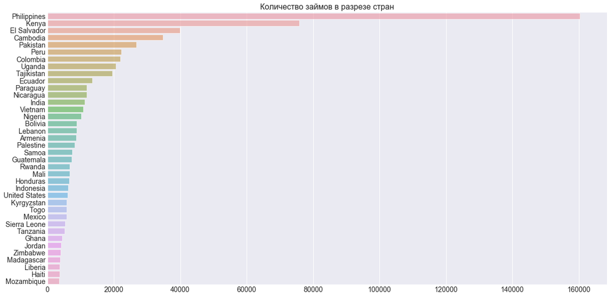

```python
plt.figure(figsize=(20,10))
plt.title("Количество займов в разрезе стран", fontsize=16)
plt.tick_params(labelsize=14)
sns.barplot(y=countries.index, x=countries.values, alpha=0.6)
plt.show()
```

**Почему на Филиппинах наибольшее количество займов?**

Чуть менее четверти всех займов приходится на Филиппины.

Возможно, потому что там широко распространены краткосрочные и небольшие займы. Давайте запомним это предположение и внимательнее рассмотрим его позже. Такая стратегия может оказаться наиболее эффективной для точечного и обширного финансирования в условиях бедности и ограниченных возможностей локальных государств.

Мы также можем заметить, что в списке присутствует множество африканских стран, таких как Кения, Мали, Нигерия, Гана. Но вообще ни одной из стран Европейского Союза. Удивительным стало присутствие США в этом списке, поскольку уровень бедности в них не такой, как в других странах.

**Группировка стран по частям света:**

```python
df_mpi.head()
```

|  | LocationName | ISO | country | region | world_region | MPI | geo | lat | lon |
| --- | --- | --- | --- | --- | --- | --- | --- | --- | --- |
| 0 | Badakhshan, Afghanistan | AFG | Afghanistan | Badakhshan | South Asia | 0.387 | (36.7347725, 70.81199529999999) | 36.734772 | 70.811995 |
| 1 | Badghis, Afghanistan | AFG | Afghanistan | Badghis | South Asia | 0.466 | (35.1671339, 63.7695384) | 35.167134 | 63.769538 |
| 2 | Baghlan, Afghanistan | AFG | Afghanistan | Baghlan | South Asia | 0.300 | (35.8042947, 69.2877535) | 35.804295 | 69.287754 |
| 3 | Balkh, Afghanistan | AFG | Afghanistan | Balkh | South Asia | 0.301 | (36.7550603, 66.8975372) | 36.755060 | 66.897537 |
| 4 | Bamyan, Afghanistan | AFG | Afghanistan | Bamyan | South Asia | 0.325 | (34.8100067, 67.8212104) | 34.810007 | 67.821210 |

```python
df_mpi_grouped = df_mpi\
    .groupby(['ISO', 'country', 'world_region'])['MPI']\
    .mean()\
    .fillna(0)\
    .reset_index()
```

```python
df_kiva_loans = df_kiva_loans.merge(df_mpi_grouped, how='left', on='country')
```

```python
regions = df_kiva_loans['world_region'].value_counts()
```

```python
regions_list = regions.index.to_list()
```

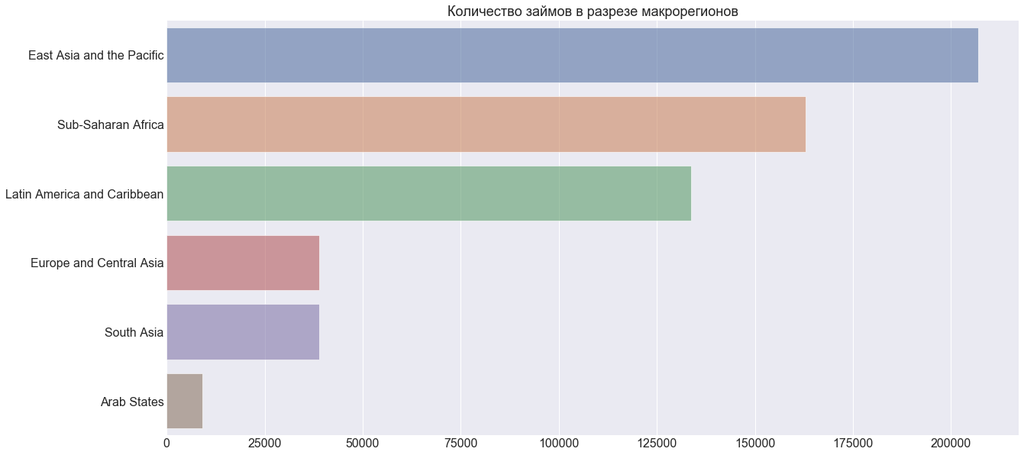

```python
plt.figure(figsize=(20,10))
sns.barplot(y=regions.index, x=regions.values, alpha=0.6)
plt.title("Количество займов в разрезе макрорегионов", fontsize=18)
plt.tick_params(labelsize=16)
plt.show();
```

Очевидным становится наличие трёх лидеров и трёх аутсайдеров по количеству выданных займов.

Исходя из этого, можно предположить, что в трёх регионах-аутсайдерах либо нет острой потребности в присутствии Kiva (относительно богатые регионы), либо она пока не набрала те обороты, что мы видим в трёх регионах-лидерах. Присутствие региона «Арабские страны» свидетельствует в пользу первого предположения.

### 2. Гендерные показатели

```python
df_kiva_loans['borrower_genders'].value_counts()
```

```
female                                                                                                                                                                                                                                                                  426502
male                                                                                                                                                                                                                                                                    134710
female, female                                                                                                                                                                                                                                                           12164
female, female, female                                                                                                                                                                                                                                                   11676
female, female, female, female                                                                                                                                                                                                                                            9052
                                                                                                                                                                                                                                                                         ...
female, female, female, female, female, female, female, female, female, female, female, female, female, female, female, female, female, female, female, female, female, male, female, female, female, female, female, female, female, female, female, female, female         1
female, female, male, female, female, female, female, female, male, male, female, female, female, male, female, male, female, female, male, female, female, female                                                                                                           1
female, male, male, female, male, female, female, female, male, male, female, female, female, female, female, female, male, male                                                                                                                                             1
female, female, male, female, female, female, female, female, female, female, female, female, male, female, female, male                                                                                                                                                     1
male, female, female, male, male, male, male, male, male, male, male, male, male, female, female                                                                                                                                                                             1
Name: borrower_genders, Length: 11298, dtype: int64
```

Выведем круговую диаграмму, используя метку **group** для заёмщиков составляющих группы людей.

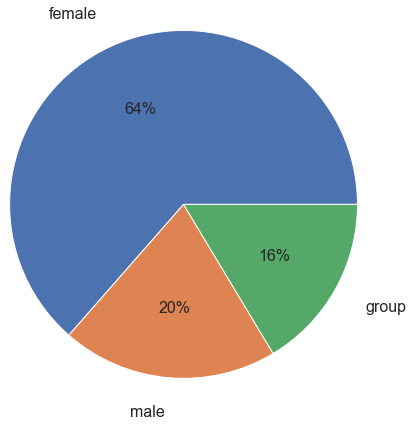

```python
df_kiva_loans['borrower_genders'] = [elem if elem in ['female','male'] else 'group' for elem in df_kiva_loans['borrower_genders'] ]
df_kiva_loans['borrower_genders']
borrowers = df_kiva_loans['borrower_genders'].value_counts()
borrowers
plot = borrowers.plot.pie(fontsize=16, autopct='%1.0f%%', labeldistance=1.2, radius=2)
```

Выясняется, что большинство заёмщиков — женщины.Это может означать, например то, что женщины используют Kiva, чтобы получить финансирование и развивать собственные проекты в странах (большинство из которых являются странами третьего мира), где традиционно женщинам это было сделать крайне тяжело.

**Выявление стран где подавляющее большинство заёмщиков — женщины**

```python
df_gender_by_country = \
    df_kiva_loans[df_kiva_loans['country'].isin(countries.index.values)]\
    .groupby(['country', 'borrower_genders'])['borrower_genders']\
    .count()\
    .groupby(level=0).apply(lambda x: 100 * x / x.sum())\
    .unstack('borrower_genders')\
    .fillna(0)\
    .sort_values(by=['female', 'male'])[-20:]

df_gender_by_country = df_gender_by_country[['female', 'male', 'group']]
df_gender_by_country
```

| borrower_genders country | female | male | group |
| --- | --- | --- | --- |
| Sierra Leone | 57.266851 | 7.959372 | 34.773777 |
| Indonesia | 58.046347 | 21.097522 | 20.856131 |
| Colombia | 58.458741 | 38.008638 | 3.532621 |
| El Salvador | 58.771160 | 39.791850 | 1.436991 |
| Lebanon | 60.748408 | 27.070064 | 12.181529 |
| Armenia | 62.368208 | 37.597034 | 0.034758 |
| Jordan | 63.618910 | 34.557235 | 1.823854 |
| Kenya | 65.570722 | 19.564787 | 14.864491 |
| Zimbabwe | 66.633614 | 3.891919 | 29.474467 |
| India | 67.295542 | 1.753137 | 30.951322 |
| Ecuador | 72.635160 | 24.236373 | 3.128467 |
| Tajikistan | 74.182840 | 25.459653 | 0.357508 |
| Haiti | 74.599226 | 22.830293 | 2.570481 |
| Madagascar | 78.304109 | 21.617378 | 0.078513 |
| Kyrgyzstan | 90.872878 | 9.109803 | 0.017319 |
| Pakistan | 93.327624 | 3.440444 | 3.231932 |
| Togo | 94.659941 | 4.853018 | 0.487041 |
| Philippines | 94.728903 | 5.221234 | 0.049863 |
| Liberia | 94.839761 | 2.906029 | 2.254210 |
| Samoa | 98.756084 | 0.919416 | 0.324500 |

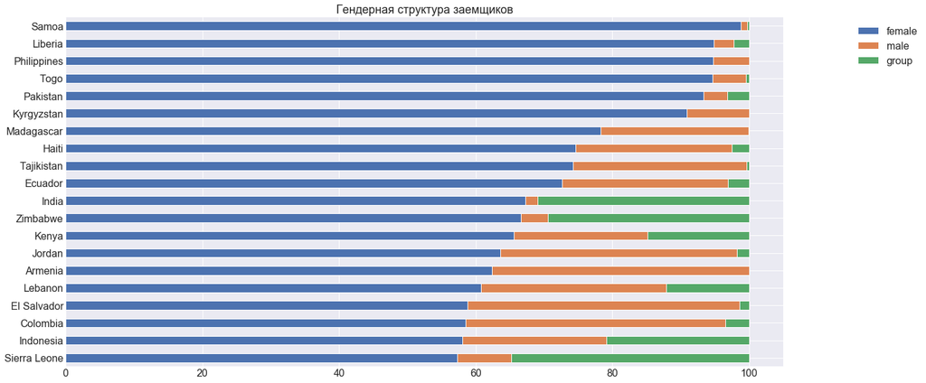

```python
plot = df_gender_by_country.plot.barh(
        figsize=(20,10)
        , fontsize=16
        , stacked=True
        , title='Гендерная структура заемщиков')
plot.title.set_size(18)
plot.legend(loc=1, bbox_to_anchor=(1.2, 1), fontsize=16)
plot.set(ylabel=None, xlabel=None)
plt.show()
```

**С чем может быть связана преобладающая доля женщин в структуре заёмщиков в разрезе стран?**

Например, в связи с направлениями, традиционно ассоциирующимися с женщинами: различного рода точки общественного питания и закусочные, магазины одежды и товаров для дома, бытовые услуги, выращивание сельскохозяйственных культур

Также можем отметить наличие в списке стран с преобладающей религией ислам, в которых женщине пока, к сожалению, отводится второстепенная роль в принятии решений. Kiva позволяет получать бОльшие возможности и перспективы в тех регионах, где ранее это было вряд ли доступно.

**Выявление стран где подавляющее большинство заёмщиков — мужчины**

```python
df_gender_by_country = \
    df_kiva_loans[df_kiva_loans['country'].isin(countries.index.values)]\
    .groupby(['country', 'borrower_genders'])['borrower_genders']\
    .count()\
    .groupby(level=0).apply(lambda x: 100 * x / x.sum())\
    .unstack('borrower_genders')\
    .fillna(0)\
    .sort_values(by=['male','female'])[-20:]

df_gender_by_country = df_gender_by_country[['male', 'female', 'group']]
df_gender_by_country
```

| borrower_genders country | male | female | group |
| --- | --- | --- | --- |
| Madagascar | 21.617378 | 78.304109 | 0.078513 |
| Haiti | 22.830293 | 74.599226 | 2.570481 |
| Rwanda | 22.865627 | 34.387528 | 42.746845 |
| Ecuador | 24.236373 | 72.635160 | 3.128467 |
| Tajikistan | 25.459653 | 74.182840 | 0.357508 |
| Lebanon | 27.070064 | 60.748408 | 12.181529 |
| Bolivia | 27.367704 | 42.414263 | 30.218033 |
| Nicaragua | 28.698752 | 50.072150 | 21.229098 |
| Honduras | 31.401556 | 57.023029 | 11.575416 |
| Peru | 32.375298 | 44.267530 | 23.357172 |
| Jordan | 34.557235 | 63.618910 | 1.823854 |
| Mexico | 34.767462 | 34.488765 | 30.743773 |
| Armenia | 37.597034 | 62.368208 | 0.034758 |
| Colombia | 38.008638 | 58.458741 | 3.532621 |
| El Salvador | 39.791850 | 58.771160 | 1.436991 |
| United States | 42.294436 | 54.981126 | 2.724438 |
| Mozambique | 48.377835 | 50.904393 | 0.717772 |
| Uganda | 48.701519 | 39.876705 | 11.421776 |
| Palestine | 64.601445 | 35.214889 | 0.183666 |
| Nigeria | 87.134964 | 11.986977 | 0.878058 |

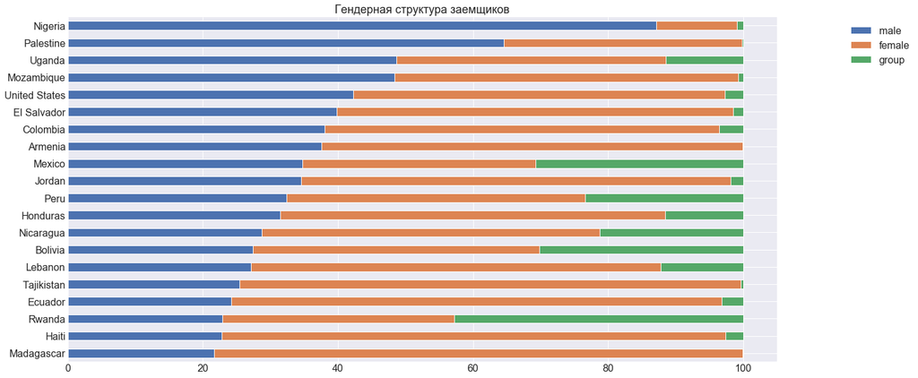

```python
plot = df_gender_by_country.plot.barh(
        figsize=(20,10)
        , fontsize=16
        , stacked=True
        , title='Гендерная структура заемщиков')
plot.title.set_size(18)
plot.legend(loc=1, bbox_to_anchor=(1.2, 1), fontsize=16)
plot.set(ylabel=None, xlabel=None)
plt.show()
```

Доля мужчин-заёмщиков значительно преобладает в **Нигерии** и **Палестине**. Это, к сожалению, не удивляет так как данные страны являются супер-патриархальными. Впрочем как и **Уганда** и **Мозамбик**, где, при этом, количество женщин и мужчин более сопоставимо друг с другом. Конечно, это может быть связано с тем, что мужчины в данных странах имеют меньшую потребность/мотивацию на использование сервиса Kiva. Но в любом случае неоспоримо, что Kiva позволяет получать бОльшие возможности и перспективы в тех регионах, где ранее это было вряд ли доступно.

## Количество займов

Выявление целей на которые людям нужны кредиты и какие суммы они просят.

### 1. В разрезе секторов

Начнём с секторов экономики. В сводке, которую мы видели выше, было 15 уникальных секторов. Рассмотрим, как обстоят дела в каждом из них.

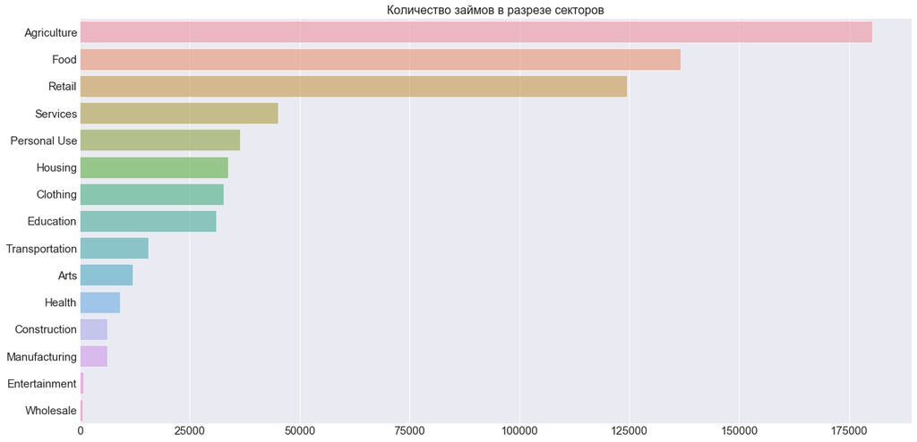

```python
sectors = df_kiva_loans['sector'].value_counts()

plt.figure(figsize=(20,10))
plt.title("Количество займов в разрезе секторов", fontsize=16)
# plt.xlabel('Number of loans', fontsize=16)
# plt.ylabel("Sectors", fontsize=16)
plt.tick_params(labelsize=15)

sns.barplot(y=sectors.index, x=sectors.values, alpha=0.6)
plt.show()
```

Самым доминирующим сектором является **сельское хозяйство**, за ним следуют **пищевая промышленность** и **торговля**. Это неудивительно, учитывая список стран, которые интенсивно используют Kiva. Например, беглый осмотр первых страниц сайта свидетельствует о таких примерах: покупка качественных семян и удобрений для использования на ферме и в садоводческом хозяйстве, закупка свежей еды, злаков, рыбы, овощей для обеспечения работы предприятия общественного питания. Можно сделать ряд выводов о структуре экономик этих стран, свидетельствующих о том, что это сугубо развивающиеся страны, полагающиеся преимущественно на аграрную отрасль.

Важно отметить, что кредиты на **личные нужды** также занимают значительную долю. Это означает, что есть люди, которые используют Kiva, потому что они крайне нуждаются.

Гораздо меньшие доли занимают **строительство**, **производство**, а также сфера **развлечений** и **оптовой торговли**.

### 2. В разрезе видов деятельности

Рассмотрим более подробную версию и сделаем подсчёт для видов деятельности.

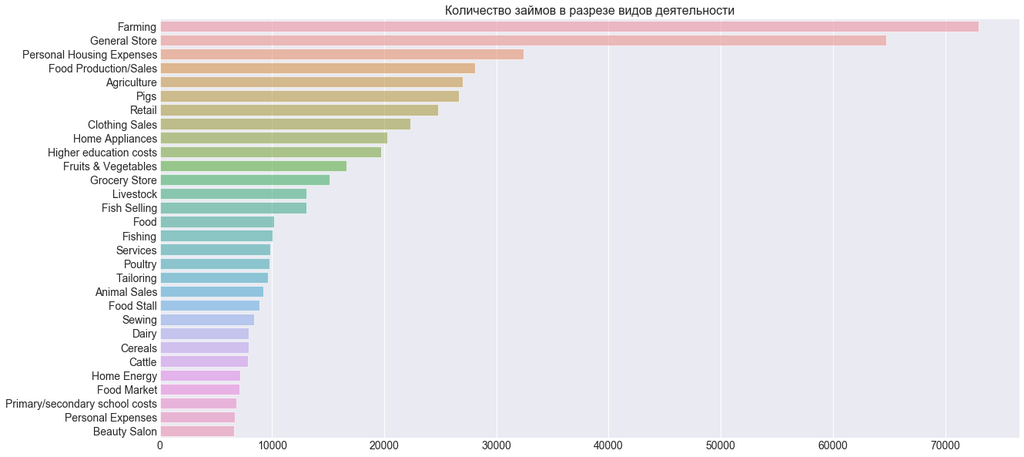

```python
activities = df_kiva_loans['activity'].value_counts().head(30)

plt.figure(figsize=(20,10))
plt.title("Количество займов в разрезе видов деятельности", fontsize=16)
plt.tick_params(labelsize=14)

sns.barplot(y=activities.index, x=activities.values, alpha=0.6)
plt.show();
```

Детализация по видам деятельности подтверждает наши наблюдения. В лидерах **фермерство**, **розничные магазины**, **домашнее хозяйство**, а также **расходы на жильё**.

### 3. Рейтинг целевого назначения займа

```python
activities = df_kiva_loans['use'].value_counts().head(25)
activities.head(25)
```

```
to buy a water filter to provide safe drinking water for their family.                                                          5217
to buy a water filter to provide safe drinking water for her family.                                                            4082
To buy a water filter to provide safe drinking water for their family.                                                          2141
to build a sanitary toilet for her family.                                                                                      1708
to build a sanitary toilet for her family                                                                                       1599
to buy ingredients for her food production business                                                                             1419
to purchase more groceries to sell.                                                                                             1409
to buy feed and other supplies to raise her pigs.                                                                               1405
to buy fertilizers and other farm supplies.                                                                                     1280
to buy a water filter to provide safe drinking water for his family.                                                            1261
to buy feed and vitamins for her pigs.                                                                                          1154
to buy feeds and other supplies to raise her pigs                                                                               1027
to buy fertilizers and other farm supplies                                                                                       970
to buy additional stocks of groceries to sell.                                                                                   888
to buy a solar lantern.                                                                                                          881
to buy more groceries to sell.                                                                                                   877
to purchase a solar light and gain access to cost efficient hybrid seeds and fertilizer for maize cultivation.\t\t\t\t\t\t\t     866
to buy feeds, vitamins, and other supplies to raise her livestock                                                                843
to buy feed, vitamins, and other supplies to raise her livestock.                                                                785
to purchase TerraClear water filters so they can have access to safe drinking water.                                             760
to buy farm inputs.                                                                                                              747
to buy fishing gear and other equipment.                                                                                         688
to build a latrine to improve the health of her family.                                                                          681
to buy ingredients for her food production business.                                                                             667
to buy feed and vitamins for her pigs                                                                                            621
Name: use, dtype: int64
```

Как видно, лидерах по целевому назначению займов — вещи, удовлетворяющие базовые человеческие потребности, такие как **покупка фильтра для воды**, **оборудование септика**, **светильники на солнечных батареях**.

### 4. Наиболее популярные виды деятельности

Наглядно сравненим наиболее популярных направлений займов. Для этого сгруппируем займы по признакам sector, activity и посмотрим на топ-10 в каждой группе.

```python
loans_by_activity_sector = \
    df_kiva_loans[df_kiva_loans['sector'].isin(sectors[:9].index.values)]\
    .groupby(['sector', 'activity'])['loan_amount']\
    .count()\
    .reset_index()
```

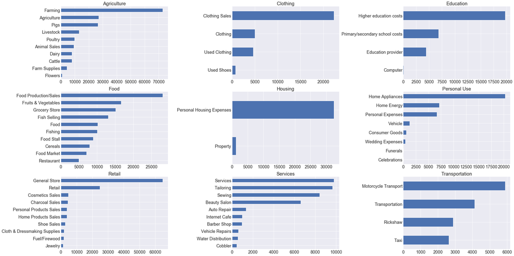

```python
fig,axes = plt.subplots(3,3, sharex=False, squeeze=False, figsize=(30,15))

for ax,q in zip(axes.ravel(), loans_by_activity_sector.sector.unique()):
    tmp_df = loans_by_activity_sector[loans_by_activity_sector.sector.eq(q)]\
                .dropna()\
                .sort_values(by='loan_amount')[-10:]
    ax.set_title(q, fontsize=20)
    ax.yaxis.label.set_visible(False)
    plt.tight_layout()

    tmp_df.plot.barh(x='activity', ax=ax, legend=None, fontsize=18)
```

Основной вывод, который мы можем сделать: львиная доля займов направлены на деятельность с невысокой добавленной стоимостью — **сельское хозяйство, розничная торговля, сервис**. То есть деятельность, в которой минимально задействованы смежные сектора экономики и невысок потенциал создания дополнительных рабочих мест и продуктов внутри страны, в отличие от, например, **производственных предприятий, строительства, ремесленных мастерских, лёгкой промышленности**.

И тем не менее не может не радовать присутствие такого направления, как, например, **образование**: финансирование обучения школах и университетах, организация и подготовка курсов и образовательных программ.

## Объём финансирования

### 1. Распределение суммы займа

Вывод на график распределение сумм займов (абсолютные значения займов, которые люди в разных странах запрашивают на реализацию своих целей могут дать важную информацию).

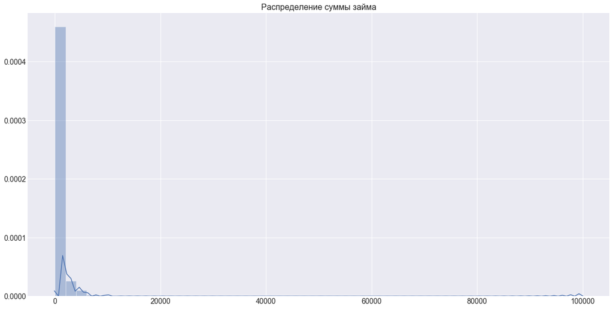

```python
plt.figure(figsize=(20,10))
plt.title("Распределение суммы займа", fontsize=16)
plt.tick_params(labelsize=14)

sns.distplot(df_kiva_loans['loan_amount'], axlabel=False)
plt.show()
```

Налицо наличие ряда предельных значений (выбросов). Они искажают распределение, и график не очень-то информативен в этой форме: нам нужно усечь данные, исключив выбросы из рассмотрения. Каким образом мы можем это сделать?

Предлагаю использовать основное, но очень мощное правило: правило трёх сигм — **68–95–99.7**. Это правило гласит, что для нормального распределения:

- 68.27% значений $ \in [\mu - \sigma , \mu + \sigma]$
- 95.45% значений $ \in [\mu - 2\sigma , \mu + 2\sigma]$
- 99.7% значений $ \in [\mu - 3\sigma , \mu + 3\sigma]$  
  где $\mu$ и $\sigma$ — среднее значение и стандартное отклонение нормального распределения.

Здесь верно, что распределение не обязательно нормальное, но для формы, подобной той, которая у нас есть, мы увидим, что применение третьего фильтра значительно улучшит качество анализа.

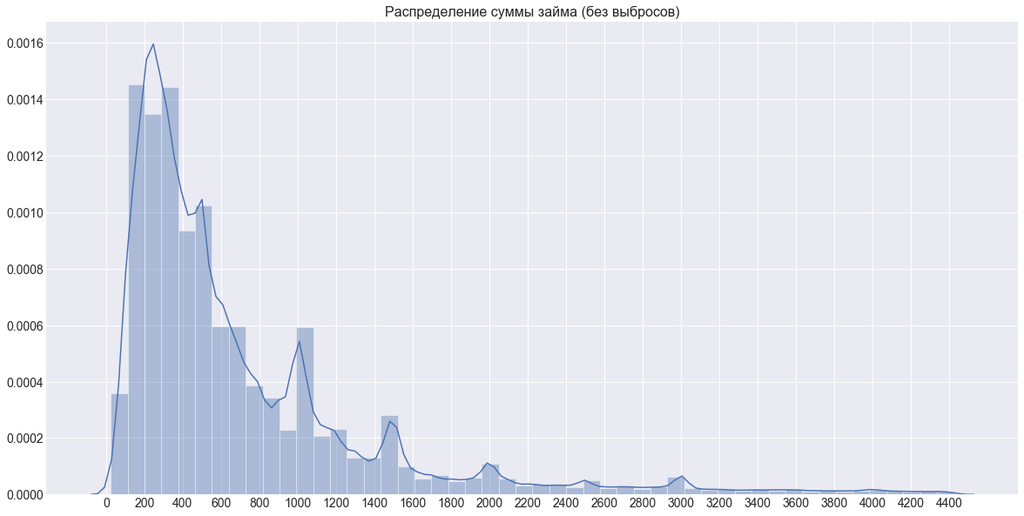

```python
# Наблюдаемое отклонение от среднего
dev = (df_kiva_loans['loan_amount']-df_kiva_loans['loan_amount'].mean()).abs()
# Стандартное отклонение
std = df_kiva_loans['loan_amount'].std()
# Фильтруем исходный набор данных
df_kiva_loans_trimmed = df_kiva_loans[~(dev>3*std)]

plt.figure(figsize=(20,10))
plt.title("Распределение суммы займа (без выбросов)", fontsize=16)
plt.tick_params(labelsize=14)
plt.xticks(np.arange(0, max(df_kiva_loans_trimmed['loan_amount']+1), 200))

sns.distplot(df_kiva_loans_trimmed['loan_amount'], axlabel=False)
plt.show()
```

- Большинство ссуд составляют от 100 до 600 долларов США с пиковыми значениями в районе 200 и 400 долларов США.
- Сумма, естественно, уменьшается, но мы можем заметить наличие её нескольких пиков в 1000 (наиболее чёткий), 1500 и 2000 долларов США. Можно предположить, что есть определённый класс проектов, которые являются более «сложными» и финансируются бОльшими суммами.

### 2. Суммы займа в разрезе секторов

**Выявление сумм кредитов в зависимости от сектора экономики**:

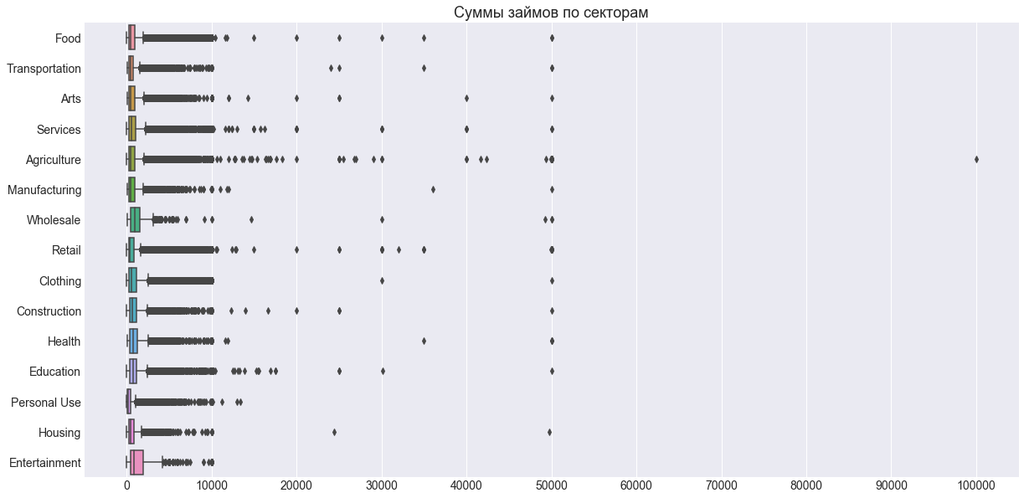

```python
plt.figure(figsize=(20,10))
plt.title("Суммы займов по секторам", fontsize=18)
plt.xticks(np.arange(0, max(df_kiva_loans['loan_amount']+1), 10000))
plt.tick_params(labelsize=14)

sns.boxplot(x='loan_amount', y="sector", data=df_kiva_loans).set(ylabel=None, xlabel=None)
plt.show()
```

Как видно, для любого сектора есть значения-выбросы. И почти для всех секторов, кроме **личные нужды, индустрия развлечений**, — наличие займов на суммы в районе **$50.000**. Например, кажется, что кто-то запросил кредит на 100 000 для сельскохозяйственного проекта. Есть также много займов на суммы 20к, 50к.

**Изучим несколько займов с очень большими суммами**:

- Что можно сказать о назначении этих заявок?
- В каких странах они оформлены?
- Каков гендерный состав заявителей?

```python
large_sums = df_kiva_loans[df_kiva_loans['loan_amount'] >= 50000]
large_sums = large_sums[['loan_amount','borrower_genders','country','sector','use']]
large_sums = large_sums.sort_values(['loan_amount','borrower_genders','country'], ascending = (False,True, True))
large_sums.head()
```

|  | loan_amount | borrower_genders | country | sector | use |
| --- | --- | --- | --- | --- | --- |
| 70499 | 100000.0 | female | Haiti | Agriculture | create more than 300 jobs for women and farmer... |
| 631904 | 50000.0 | female | Cote D'Ivoire | Agriculture | double cashew nut export output and hire about... |
| 565733 | 50000.0 | female | Ecuador | Agriculture | to pay 600 farming families 100% above market ... |
| 614922 | 50000.0 | female | Ghana | Services | to set up 13 new clean water businesses in nor... |
| 657346 | 50000.0 | female | Ghana | Services | Impact Hub Accra improve its innovation and en... |

Самый большой кредит в **100k** был запрошен женщиной из Гаити для сектора Агрокультуры и предназначен для создания более 300 рабочих мест что объясняет такой объем необходимых средств.

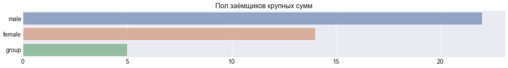

```python
gen_cnt = large_sums['borrower_genders'].value_counts()

plt.figure(figsize=(20,2))
plt.title("Пол заёмщиков крупных сумм", fontsize=16)
plt.tick_params(labelsize=14)
sns.barplot(y=gen_cnt.index, x=gen_cnt.values, alpha=0.6)
plt.show()
```

Количество мужчин-заёмщиков крупных сумм превышает количество заёмщиков женского пола примерно в полтора раза.

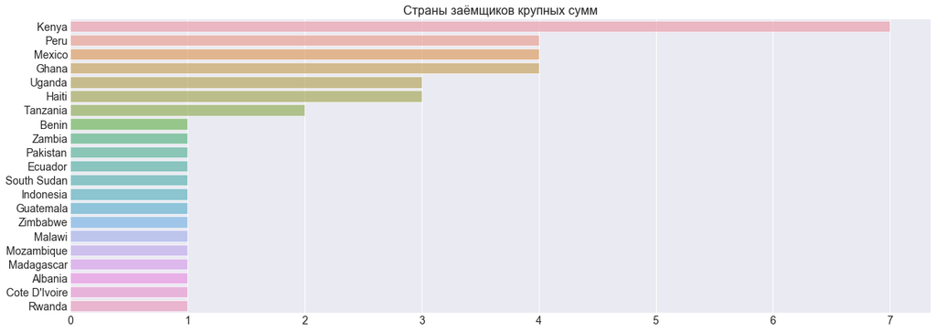

```python
country_cnt = large_sums['country'].value_counts()

plt.figure(figsize=(20,7))
plt.title("Страны заёмщиков крупных сумм", fontsize=16)
plt.tick_params(labelsize=14)
sns.barplot(y=country_cnt.index, x=country_cnt.values, alpha=0.6)
plt.show()
```

Наибольшее число людей, нуждаюшихся в крупных суммах, находятся в странах Африки. Из всех стран по количеству людей с займами от 50к лидирует Кения.

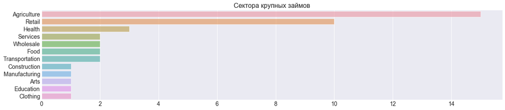

```python
sector_cnt = large_sums['sector'].value_counts()

plt.figure(figsize=(20,4))
plt.title("Сектора крупных займов", fontsize=16)
plt.tick_params(labelsize=14)
sns.barplot(y=sector_cnt.index, x=sector_cnt.values, alpha=0.6)
plt.show()
```

Данные суммы требовались преимущественно для сельскохозяйственного сектора и сектора розничной торговли.

Выявление **средних и медианных значений сумм займа по секторам**:

```python
sector_mean_median = df_kiva_loans\
    .groupby(['sector'])['loan_amount']\
    .agg(median='median', mean='mean')\
    .sort_values(by='median', ascending=False)

sort_order = sector_mean_median.index.to_list()

sector_mean_median
```

| sector | median | mean |
| --- | --- | --- |
| Wholesale | 950.0 | 1569.716088 |
| Entertainment | 887.5 | 1673.674699 |
| Education | 725.0 | 998.565924 |
| Health | 725.0 | 1067.266616 |
| Construction | 700.0 | 1068.147735 |
| Clothing | 600.0 | 1139.237829 |
| Services | 550.0 | 1064.631148 |
| Agriculture | 500.0 | 793.490228 |
| Housing | 500.0 | 701.549020 |
| Manufacturing | 500.0 | 877.561211 |
| Arts | 475.0 | 1014.952322 |
| Food | 450.0 | 889.864039 |
| Transportation | 450.0 | 713.165356 |
| Retail | 425.0 | 788.173727 |
| Personal Use | 200.0 | 411.030644 |

**Избавление от выбросов и вывод на график**:

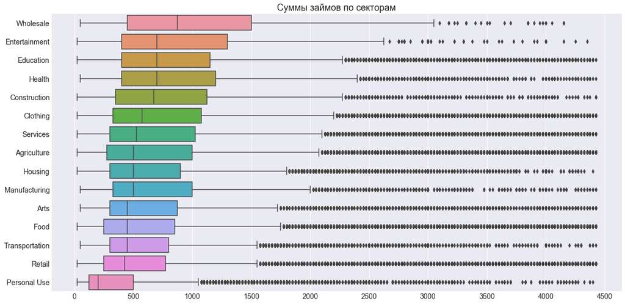

```python
plt.figure(figsize=(20,10))
plt.title("Суммы займов по секторам", fontsize=18)
plt.xticks(np.arange(0, max(df_kiva_loans['loan_amount']+1), 500))
plt.tick_params(labelsize=14)

sns.boxplot(x='loan_amount', y="sector", order=sort_order, data=df_kiva_loans_trimmed).set(ylabel=None, xlabel=None)
plt.show()
```

Прежде всего нужно отметить, что именно медиана даёт устойчивую к выбросам оценку центрального положения суммы займа.

Из графика становится ясно, что медиана суммы заявок на **личные нужды** обладает наименьшим значением. Личные нужды включают предметы обихода и первой необходимости, обеспечение жилища энергией, теплом и водой. Именно эта группа заявок может свидетельствовать о случаях крайней нужды и бедности в различных странах.

На другой стороне графика сектора с самыми большими показателями медианы суммы займа: **оптовая торговля**, требующая значительных затрат на закупку, что вполне логично; **образование** и **здравоохранение**, а также **сфера развлечений**.

### 3. Распределение по макрорегионам

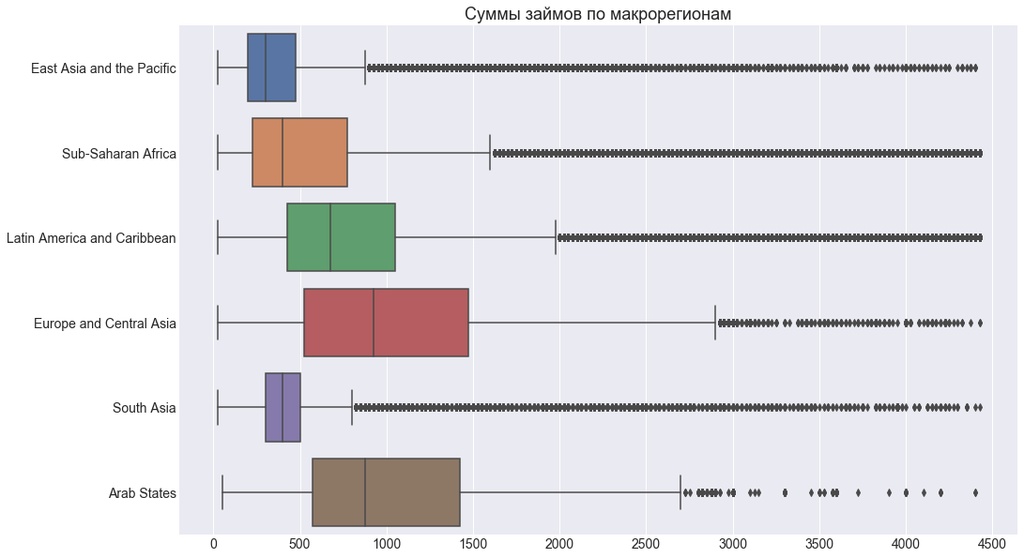

```python
plt.figure(figsize=(16,10))
plt.title("Суммы займов по макрорегионам", fontsize=18)
plt.xticks(np.arange(0, max(df_kiva_loans['loan_amount']+1), 500))
plt.tick_params(labelsize=14)

sns.boxplot(x='loan_amount', y="world_region", order=regions_list, data=df_kiva_loans_trimmed)\
    .set(ylabel=None, xlabel=None)
# plt.legend(loc=1, bbox_to_anchor=(1.15, 1), fontsize=16)
plt.show()
```

Регионы расположены в порядке убывания количества займов (в соответствии с графиком, полученным в п. 2.2.1).

Скорее всего, те регионы, в которых медианные значения ниже, в целом беднее и требуют финансирования короткими, небольшими, но частыми займами. Эту ситуацию мы и наблюдаем в регионе **Юго-Восточная Азия**, лидерами в котором являются **Филиппины** и **Камбоджа**.

Однако на этом графике мы можем заметить регион, который выбивается из последовательности, — **Южная Азия**, а в частности такие страны, как **Пакистан** и **Индия**. Вполне вероятно, что в этом регионе есть отличная площадка для расширения присутствия и поддержки со стороны сообщества Kiva.

Поиск **связи между странами (макрорегионами), полом заёмщика и суммой заявки**.

```python
gen_reg_loan_tmp = df_kiva_loans.groupby(["world_region","borrower_genders"])#.median("loan_amount")
gen_reg_loan = gen_reg_loan_tmp.agg("median")
df_gen_reg_loan = gen_reg_loan["loan_amount"].to_frame()
df_gen_reg_loan
```

| world_region | borrower_genders | loan_amount |
| --- | --- | --- |
| Arab States | female | 1000.0 |
|  | group | 950.0 |
|  | male | 750.0 |
| East Asia and the Pacific | female | 300.0 |
|  | group | 200.0 |
|  | male | 450.0 |
| Europe and Central Asia | female | 900.0 |
|  | group | 1000.0 |
|  | male | 1000.0 |
| Latin America and Caribbean | female | 625.0 |
|  | group | 1950.0 |
|  | male | 600.0 |
| South Asia | female | 375.0 |
|  | group | 825.0 |
|  | male | 1050.0 |
| Sub-Saharan Africa | female | 300.0 |
|  | group | 1050.0 |
|  | male | 350.0 |

```python
df_gen_reg_loan_reconst = df_gen_reg_loan.unstack(['borrower_genders']).sum(axis=1,level=['borrower_genders'])
```

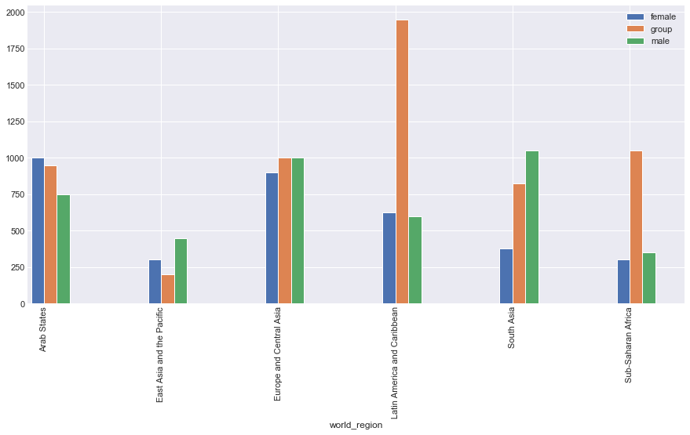

```python
import itertools
palette = itertools.cycle(sns.color_palette())

#spcify the relative position of each bar
n = len(list(df_gen_reg_loan_reconst))
positions = np.linspace(n/3., -n/3., n)

# plot each column individually
for i,col in enumerate(list(df_gen_reg_loan_reconst)):
    c = next(palette)
    pos = positions[i]
    df_gen_reg_loan_reconst[col].plot(kind='bar',position=pos, color=c, width=0.11, figsize=(15, 7))

plt.legend()
plt.show()
```

В большинстве регионов женщины запрашивают несколько меньшую сумму займа на свои нужды, нежели мужчины. Возможно, это связано тем что в странах азии и в мусульманских странах женщинам до сих пор отводится второстепенная роль в принятии решений и это так или иначе влияет на мироощущение женщин. Даже во многих регионах России женщины с идентичным уровнем навыков что и мужчины просят, к примеру, меньшую заработную плату и это до сих пор считается нормой. При этом мы видим что в Арабских государствах медианный уровень займа выше у пользователей женского пола. Вероятнее всего, это связано с тем, что данные страны являются богатыми с высоким уровнем ВВП) и при этом женщинам в них в также отводится второстепенная роль: работа и бизнес, как правило, для мужчин, т.е. мужчины зарабатывают больше и имеют меньше потребности в использовании сервиса Kiva. Женщины же могут рассматривать Kiva как сервис дающий реальные перспективы бОльших возможностей для самостоятельного бизнеса.

### 4. Зависимость пола заёмщика от региона планеты, сектора экономики

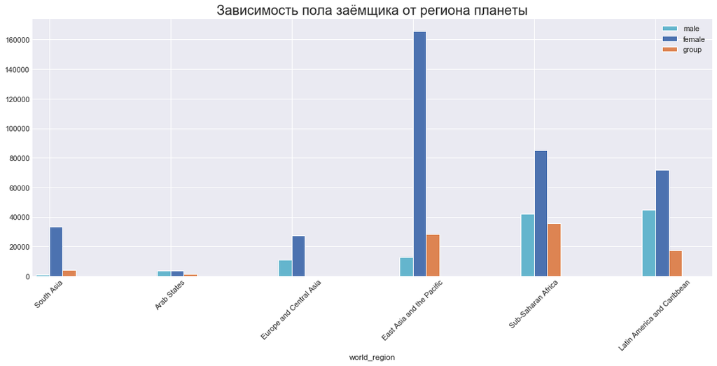

```python
regions = df_kiva_loans["world_region"].value_counts()[df_kiva_loans["world_region"].value_counts(normalize=True)> 0.005]
list_countries = list(regions.index)

df_gender_by_reg = \
    df_kiva_loans[df_kiva_loans["world_region"].isin(regions.index.values)]\
    .groupby(["world_region", 'borrower_genders'])['borrower_genders']\
    .count()\
    .unstack('borrower_genders')\
    .sort_values(by=['male','female'])

df_gender_by_reg = df_gender_by_reg[['male', 'female', 'group']]

#spcify the relative position of each bar
n = len(list(df_gender_by_reg))
positions = np.linspace(n/3., -n/3., n)

# plot each column individually
for i,col in enumerate(list(df_gender_by_reg)):
    c = next(palette)
    pos = positions[i]
    df_gender_by_reg[col].plot(kind='bar',position=pos, color=c, width=0.11, figsize=(18, 7), rot=45)
plt.title("Зависимость пола заёмщика от региона планеты", fontsize=20)
plt.legend()
plt.show()
```

Практически во всех макрорегиона значительно преобладает количество женщин, использующих Kiva для получения займа. Рассмотрим зависимость пола от сектора экономики.

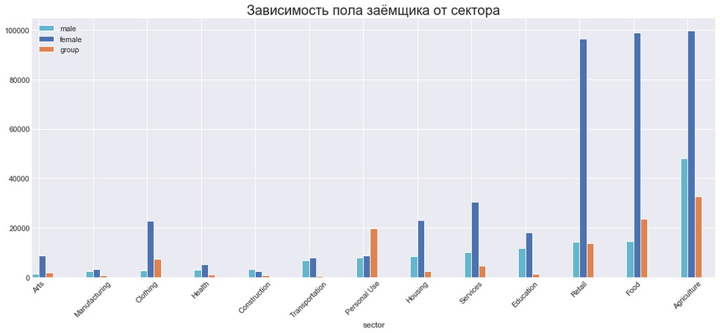

```python
sector = df_kiva_loans["sector"].value_counts()[df_kiva_loans["sector"].value_counts(normalize=True)> 0.005]
list_sector = list(sector.index)

df_gender_by_sector = \
    df_kiva_loans[df_kiva_loans["sector"].isin(sector.index.values)]\
    .groupby(["sector", 'borrower_genders'])['borrower_genders']\
    .count()\
    .unstack('borrower_genders')\
    .sort_values(by=['male','female'])

df_gender_by_sector = df_gender_by_sector[['male', 'female', 'group']]
sns.set_style("darkgrid")
#spcify the relative position of each bar
n = len(list(df_gender_by_sector))
positions = np.linspace(n/3, -n/3, n)

# plot each column individually
for i,col in enumerate(list(df_gender_by_sector)):
    c = next(palette)
    pos = positions[i]
    df_gender_by_sector[col].plot(kind='bar',position=pos, color=c, width=0.13, figsize=(18, 7), rot=45)

plt.title("Зависимость пола заёмщика от сектора", fontsize=20)
plt.legend()
plt.show()
```

## Время ожидания средств

- **posted_time**: соответствует дате + точный час, когда заявка появилась на сайте.
- **disbursed_time**: соответствует дате + точный час, когда деньги фактически были получены адресатом.
1. Отбрасываем строки с пропущенными значениями для «disbursed_time», получаем столбцы в правильном формате.
2. Вычисляем интервал между датами.
3. Исключим из рассмотрения заявки, для которых деньги сначала фактически выдаются агентами на местах и только потом публикуются на сайте.

```python
# drop na (missing) values
df_loans_dates = df_kiva_loans_trimmed.dropna(subset=['disbursed_time', 'funded_time'], how='any', inplace=False)

# dates columns:
dates = ['posted_time','disbursed_time']

# format dates:
df_loans_dates[dates] = df_loans_dates[dates].applymap(lambda x : x.split('+')[0])
df_loans_dates[dates] = df_loans_dates[dates].apply(pd.to_datetime)

# calculate time interval
df_loans_dates.loc[:, 'time_funding'] = df_loans_dates['disbursed_time']-df_loans_dates['posted_time']
df_loans_dates.loc[:, 'time_funding'] = df_loans_dates['time_funding'] / timedelta(days=1)

# remove outliers +-3 sigma
dev = (df_loans_dates['time_funding']-df_loans_dates['time_funding'].mean()).abs()
std = df_loans_dates['time_funding'].std()

# Keep rows where time_funding interval > 0 only
df_loans_dates_trimmed = df_loans_dates[~(dev>3*std) & (df_loans_dates.loc[:, 'time_funding']>0)]
```

### 1. Количество дней до полного финансирования заявки

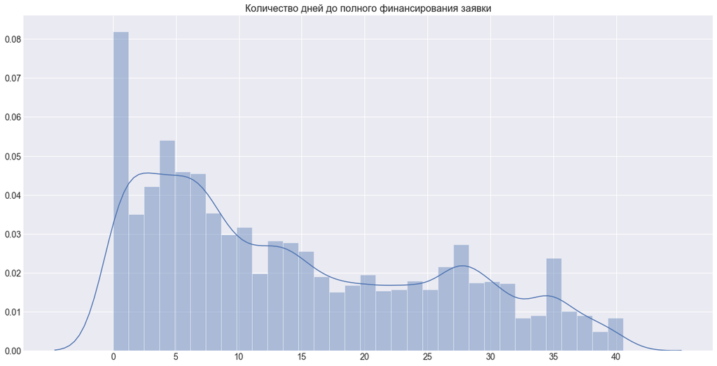

```python
plt.figure(figsize=(20,10))
plt.title("Количество дней до полного финансирования заявки", fontsize=16)
plt.xticks(np.arange(0, max(df_loans_dates_trimmed['time_funding']+1), 5))
plt.tick_params(labelsize=14)

sns.distplot(df_loans_dates_trimmed['time_funding']).set(ylabel=None, xlabel=None)
plt.show()
```

Однако также очевидно и наличие пиков в районе 27, 35 дней. Это уже может свидетельствовать о том, что часть заявок проходят довольно длительный процесс финансирования.

### 2. Время ожидания и суммы займов

Выводим **тепловую карту** для визуализации зависимости суммы займа и временного интервала финансирования.

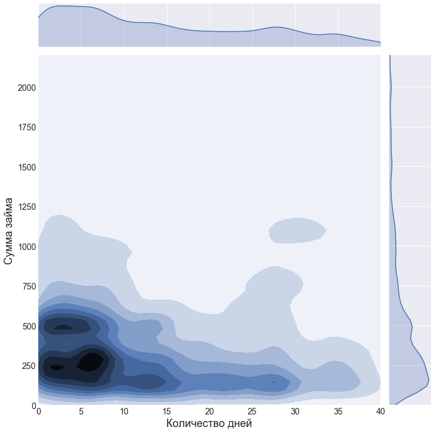

```python
p = sns.jointplot(x="time_funding", y="loan_amount", data=df_loans_dates_trimmed, kind='kde', height=10, ratio=7, xlim=[0,40] , ylim=[0,2200])\
        .set_axis_labels("Количество дней", "Сумма займа", size=18)

# p.ax_joint.set_xticks(np.arange(0, max(df_loans_dates_trimmed['time_funding']+1), 5))
# p.ax_joint.set_yticks(np.arange(0, max(df_loans_dates_trimmed['loan_amount']+1), 250))
p.ax_joint.tick_params(labelsize=14)

plt.show()
```

На тепловой карте области, выделенные одним цветом, содержат одинаковое количество заявок. При этом области с более насыщенными, тёмными цветами содержат бОльшее количество заявок, чем более светлые области.

Действительно, возрастающее количество дней, требуемое для финансирования заявки, можно объяснить возрастающей суммой, но только отчасти.

Мы также можем видеть наличие большого количества заявок на суммы до **$250** со сроками **20–35** дней. Kiva явно может предпринять что-то, чтобы люди чаще обращали внимание на такие заявки.

### 3. Время ожидания и страны

Давайте попробуем проверить наличие смещения интервалов ожидания по странам, то есть предположение о том, что заявки из ряда стран финансируются необоснованно долго в силу тех или иных причин.

```python
df_country_median = df_loans_dates_trimmed.groupby(['world_region', 'country'])\
    .agg({'loan_amount' : 'median', 'time_funding' : 'median', 'term_in_months' : 'median'})\
    .reset_index()

df_country_median = df_country_median[df_country_median.country.isin(list_countries)].sort_values(by='time_funding')
```

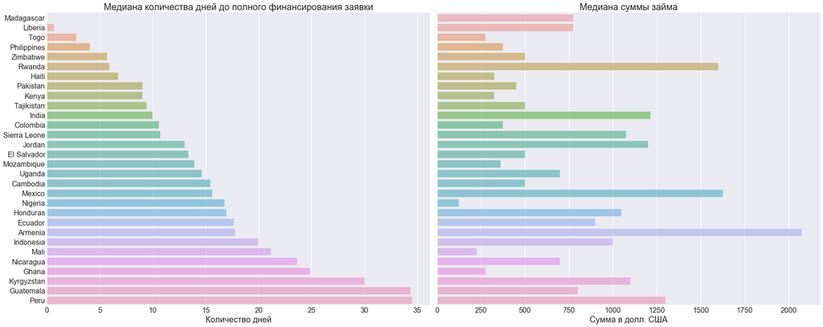

```python
f,ax=plt.subplots(1, 2, sharey=True, figsize=(25,10))

sns.barplot(y='country', x='time_funding', data=df_country_median, alpha=0.6, ax=ax[0])
ax[0].set_title("Медиана количества дней до полного финансирования заявки", fontsize=20)
ax[0].set_xlabel('Количество дней', fontsize=18)
ax[0].set_ylabel(None)
ax[0].tick_params(labelsize=16)

sns.barplot(y='country', x='loan_amount', data=df_country_median, alpha=0.6, ax=ax[1])
ax[1].set_title("Медиана суммы займа", fontsize=20)
ax[1].set_xlabel('Сумма в долл. США', fontsize=18)
ax[1].set_ylabel(None)
ax[1].tick_params(labelsize=16)

plt.tight_layout()
plt.show()
```

Действительно, прямой связи времени ожидания финансирования и суммой займа не наблюдается.

В ряде стран с довольно большой медианной суммой займа наблюдаются короткие интервалы на сбор средств:

- Либерия: **750** USD — **1** день;
- Руанда: **1600** USD — **5** дней;
- Индия: **1250** USD — **10** дней.

И наоборот, в нескольких странах на сбор относительно небольших сумм требуется длительное время:

- Нигерия: **125** USD — **17** дней;
- Мали: **250** USD — **22** дня;
- Гана: **250** USD — **25** дней.

## Сумма кредита и время погашения

Необходимо изучить информацию о количестве месяцев, необходимых заёмщикам для погашения своих кредитов. Так как простое построение среднего/медианного времени погашения по стране может дать некоторую информацию, но также и может ввести в заблуждение, более важно именно **соотношение суммы кредита и времени погашения**. Оно даёт представление о том, сколько денег в месяц человек в данной стране может позволить себе тратить на погашение кредитов.

### 1. Расчёт суммы ежемесячного платежа в разрезе стран

```python
df_country_median = df_country_median.sort_values(by='term_in_months')
```

```python
df_country_median['monthly_repayment'] = df_country_median['loan_amount'] / df_country_median['term_in_months']
```

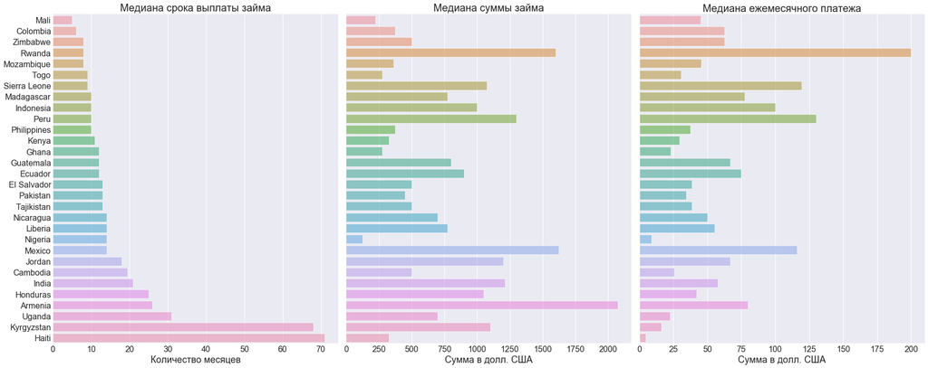

```python
f,ax=plt.subplots(1, 3, sharey=True, figsize=(25,10))

sns.barplot(y='country', x='term_in_months', data=df_country_median, alpha=0.6, ax=ax[0])
ax[0].set_title("Медиана срока выплаты займа", fontsize=20)
ax[0].set_xlabel('Количество месяцев', fontsize=18)
ax[0].set_ylabel(None)
ax[0].tick_params(labelsize=16)

sns.barplot(y='country', x='loan_amount', data=df_country_median, alpha=0.6, ax=ax[1])
ax[1].set_title("Медиана суммы займа", fontsize=20)
ax[1].set_xlabel('Сумма в долл. США', fontsize=18)
ax[1].set_ylabel(None)
ax[1].tick_params(labelsize=16)

sns.barplot(y='country', x='monthly_repayment', data=df_country_median, alpha=0.6, ax=ax[2])
ax[2].set_title("Медиана ежемесячного платежа", fontsize=20)
ax[2].set_xlabel('Сумма в долл. США', fontsize=18)
ax[2].set_ylabel(None)
ax[2].tick_params(labelsize=16)

plt.tight_layout()
plt.show()
```

Перед нами наглядное представление о рейтинге беднейших стран, люди из которых пользуются платформой Kiva. Это страны, в которых люди могут позволить себе выплачивать суммы значительно меньшие, чем в других странах, — а значит, и уровень бедности там выше.

- Гаити;
- Нигерия;
- Киргизия;
- Уганда;
- Гана.

Как никогда стоит обратить внимание сообщества Kiva и направить усилия на поддержку самых нуждающихся!

### 2. Влияние такого атрибута займа, как Количество кредиторов (lender_count) на суммы и сроки займов

```python
df_lenders_median = df_kiva_loans_trimmed.groupby(["lender_count"])\
    .agg({'loan_amount' : 'median', 'term_in_months' : 'median'})\
    .reset_index()
```

```python
groupped_lenders = pd.cut(df_lenders_median["lender_count"], bins=6, right=False, precision=0).to_frame()
groupped_lenders
free_lenders = df_lenders_median.drop(["lender_count"], axis=1)
free_lenders
joined_lenders = groupped_lenders.join(free_lenders)
joined_lenders
```

|  | lender_count | loan_amount | term_in_months |
| --- | --- | --- | --- |
| 0 | [0.0, 45.0) | 525.0 | 14.0 |
| 1 | [0.0, 45.0) | 250.0 | 8.0 |
| 2 | [0.0, 45.0) | 225.0 | 8.0 |
| 3 | [0.0, 45.0) | 150.0 | 8.0 |
| 4 | [0.0, 45.0) | 150.0 | 8.0 |
| ... | ... | ... | ... |
| 176 | [179.0, 223.0) | 4000.0 | 24.0 |
| 177 | [179.0, 223.0) | 3500.0 | 24.0 |
| 178 | [223.0, 268.0) | 4000.0 | 12.0 |
| 179 | [223.0, 268.0) | 4000.0 | 24.0 |
| 180 | [223.0, 268.0) | 4000.0 | 24.0 |

181 rows × 3 columns

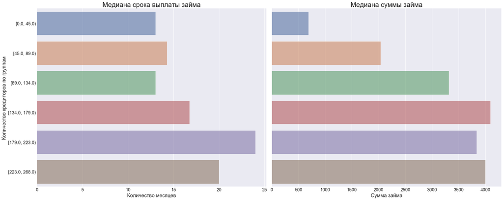

```python
f,ax=plt.subplots(1, 2, sharey=True, figsize=(25,10))

sns.barplot(y='lender_count', x='term_in_months', data=joined_lenders, alpha=0.6, ax=ax[0], ci = None)
ax[0].set_title("Медиана срока выплаты займа", fontsize=24)
ax[0].set_xlabel('Количество месяцев', fontsize=18)
ax[0].set_ylabel('Количество кредиторов по группам', fontsize=18)
ax[0].tick_params(labelsize=16)

sns.barplot(y='lender_count', x='loan_amount', data=joined_lenders, alpha=0.6, ax=ax[1], ci = None)
ax[1].set_title("Медиана суммы займа", fontsize=24)
ax[1].set_xlabel('Сумма займа', fontsize=18)
ax[1].set_ylabel(None)
ax[1].tick_params(labelsize=16)

plt.tight_layout()
plt.show()
```

Для удобства анализа данных, количество кредиторов было распределено по группам.  
Явно видно, что количество чем больше сумма займа, тем требуется больше кредиторов для её финансирования.  
Связь между количество кредиторов и сроком выплаты займа также прослеживается. Хотя она не так ярко выражена и данном случае это может быть связано со многими факторами:

- уровень бедности заёмщика (что может требовать больше времени на выплату даже небольшой суммы займа)
- цель для которой был взят кредит (что может, например, влить на срок когда заёмщик сможет заработать деньги на своём новом бизнесе, чтобы вернуть всем кредиторам)
- факт того, был ли это один заёмщик или большая группа людей

### 3. Влияние показателя MPI (многомерный индекс бедности) в разных странах на суммы займов и сроки погашения

```python
df_lenders_median2 = df_kiva_loans_trimmed.groupby(["country","MPI"])\
    .agg({'loan_amount' : 'median', 'term_in_months' : 'median'})\
    .sort_values("MPI")
df_lenders_median2.tail(5)
```

| country | MPI | loan_amount | term_in_months |
| --- | --- | --- | --- |
| Liberia | 0.433867 | 275.0 | 11.0 |
| Mali | 0.444833 | 1000.0 | 8.0 |
| Sierra Leone | 0.481071 | 700.0 | 10.0 |
| Burkina Faso | 0.547692 | 975.0 | 8.0 |
| South Sudan | 0.549778 | 300.0 | 7.0 |

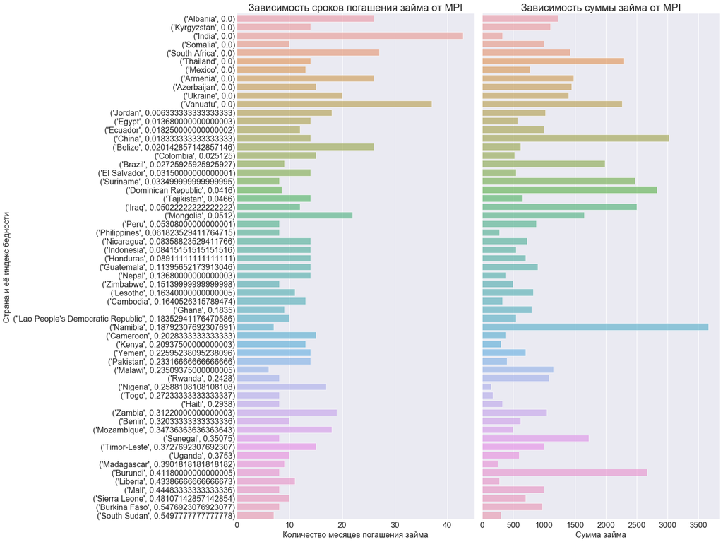

```python
f,ax=plt.subplots(1, 2, sharey=True, figsize=(20,15))

sns.barplot(y=df_lenders_median2.index, x=df_lenders_median2['term_in_months'], data=df_lenders_median2, alpha=0.6, ax=ax[0])
ax[0].set_title("Зависимость сроков погашения займа от MPI", fontsize=20)
ax[0].set_xlabel('Количество месяцев погашения займа', fontsize=16)
ax[0].set_ylabel('Страна и её индекс бедности', fontsize=16)
ax[0].tick_params(labelsize=16)

sns.barplot(y=df_lenders_median2.index, x=df_lenders_median2['loan_amount'], data=df_lenders_median2, alpha=0.6, ax=ax[1], ci = None)
ax[1].set_title("Зависимость суммы займа от MPI", fontsize=20)
ax[1].set_xlabel('Сумма займа', fontsize=16)
ax[1].set_ylabel(None)
ax[1].tick_params(labelsize=16)

plt.tight_layout()
plt.show()
```

Видно, что странам с низким индексом бедности требуется больше времени на погашение кредита, что (судя по графику) может быть связано с суммой займа, а также его целью и в ряде случаев сектору экономики (в разных регионах стоимость бизнеса разная и специфика сектора также играет роль).  
Заёмщики же из более бедных стран запрашивают(как правило) меньшие суммы, но и выплачивают их в более короткие сроки. Хотя данный показатель является относительным так так, несмотря на то что сроки небольшие, они часто сопоставимы со сроками выплатыы кредита заёмщиками из более богатых стран, которые брали бОльшие суммы.

### 4. Взаимозависимости таких метрик, как «Сумма займа», «Срок займа», «Время финансирования заявки», «Ежемесячный платёж» в разрезе **макрорегионов**.

```python
df_loans_dates_trimmed_copy = df_loans_dates_trimmed.copy()
df_loans_dates_trimmed_copy.loc[:, 'monthly_repayment'] = df_loans_dates_trimmed_copy['loan_amount'] / df_loans_dates_trimmed_copy['term_in_months']

macro = df_loans_dates_trimmed_copy[["world_region","loan_amount","time_funding","term_in_months","monthly_repayment"]]
macro = macro.set_index("world_region")
#macro

macro_med = macro.groupby(macro.index)\
    .agg({'loan_amount' : 'median', 'term_in_months' : 'median', 'time_funding' : 'median', 'monthly_repayment' : 'median'})
macro_med
```

| world_region | loan_amount | term_in_months | time_funding | monthly_repayment |
| --- | --- | --- | --- | --- |
| Arab States | 650.0 | 14.0 | 3.776863 | 46.428571 |
| East Asia and the Pacific | 575.0 | 10.0 | 9.963727 | 52.272727 |
| Europe and Central Asia | 1100.0 | 66.0 | 27.837870 | 16.417910 |
| Latin America and Caribbean | 750.0 | 13.0 | 18.583750 | 56.250000 |
| South Asia | 1112.5 | 21.0 | 9.744039 | 35.465116 |
| Sub-Saharan Africa | 300.0 | 13.0 | 11.614763 | 38.461538 |

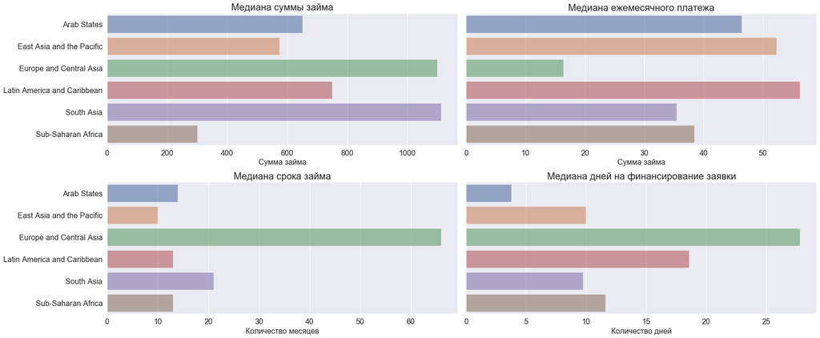

```python
f,ax=plt.subplots(2, 2, sharey=True, figsize=(24,10))

sns.barplot(y=macro_med.index, x='loan_amount', data=macro_med, alpha=0.6, ax=ax.flatten()[0], ci = None)
ax.flatten()[0].set_title("Медиана суммы займа", fontsize=20)
ax.flatten()[0].set_xlabel("Сумма займа", fontsize=16)
ax.flatten()[0].set_ylabel(None)
ax.flatten()[0].tick_params(labelsize=16)

sns.barplot(y=macro_med.index, x='monthly_repayment', data=macro_med, alpha=0.6, ax=ax.flatten()[1], ci = None)
ax.flatten()[1].set_title("Медиана ежемесячного платежа", fontsize=20)
ax.flatten()[1].set_xlabel("Сумма займа", fontsize=16)
ax.flatten()[1].set_ylabel(None)
ax.flatten()[1].tick_params(labelsize=16)

sns.barplot(y=macro_med.index, x='term_in_months', data=macro_med, alpha=0.6, ax=ax.flatten()[2], ci = None)
ax.flatten()[2].set_title("Медиана срока займа", fontsize=20)
ax.flatten()[2].set_xlabel("Количество месяцев", fontsize=16)
ax.flatten()[2].set_ylabel(None)
ax.flatten()[2].tick_params(labelsize=16)

sns.barplot(y=macro_med.index, x='time_funding', data=macro_med, alpha=0.6, ax=ax.flatten()[3], ci = None)
ax.flatten()[3].set_title("Медиана дней на финансирование заявки", fontsize=20)
ax.flatten()[3].set_xlabel('Количество дней', fontsize=16)
ax.flatten()[3].set_ylabel(None)
ax.flatten()[3].tick_params(labelsize=16)

plt.tight_layout()
plt.show()
```

# Результаты и выводы

Пора подвести основные итоги и сделать выводы, которые могут быть полезны и интересны не только организаторам платформы Kiva, но и всему сообществу неравнодушных людей, которые стремятся сделать этот мир немного лучше.

- Прежде всего необходимо отметить очень важную и знаменательную роль площадки Kiva и её сообщества. Для большого числа людей в совершенно разных частях нашей планеты Kiva играет важнейшую роль в части **поддержки операционной и хозяйственной деятельности**, активно дополняя, а часто выступая в роли частного банковского сектора.
- В каждый момент времени стоит оказывать **адресную помощь** странам и регионам, которые больше всего **недофинансированы** относительно других. Это страны с высоким уровнем бедности, в которых люди могут позволить себе выплачивать суммы значительно мЕньшие, чем в других странах. Как никогда стоит обратить внимание сообщества Kiva и направить усилия на **поддержку самых нуждающихся**! Такие заявки могут быть отражены в отдельных категориях и включать призывы в свои заголовки: *Неотложные нужды, Срочно, Истекает срок финансирования*.
- Используя положительный опыт Филиппин, стоит стимулировать рост выдачи небольших по сумме и сроку погашения займов, которые обеспечат **бОльшую занятость** населения и рост **деловой активности**. По возможности, стоит делить заявки из небогатых стран на небольшие и короткие займы, каждый из которых будет очередным маленьким шагом в большом деле.
- Когда дело касается возможностей для развития человека — границы между мужчинами и женщинами стираются. Стоит стремиться к обеспечению доступа к финансированию для **женщин и мужчин в равной степени** и обратить внимание на те страны и регионы, где пока этот баланс нарушен. Например, для таких стран, как Самоа, Либерия, Того, выводить на главную страницу сначала займы от мужчин. Отличным шагом станет публикация личных историй и примеров женщин и мужчин, например, в **интернет-издательствах**, на **блогинг-платформах**, таких как medium.com, а также в видеоблоге Kiva на youtube.com.
- Приоритетными должны становиться заявки, направленные на развитие отраслей с **высокой добавленной стоимостью и стимулированием производств**, так как они являются движущей силой и по цепочке начинают задействовать другие отрасли. А именно **строительство, производство, лёгкая промышленность**. Здесь очень кстати будет использование **умных рекомендательных систем** на сайте Kiva.org, которые с бОльшей вероятностью будут подсказывать такие заявки.
- Всё ещё довольна высока доля заявок, направленных на удовлетворение самых **базовых человеческих потребностей**. Такие просьбы не должны оставаться незамеченными, но быть первыми кандидатами на главной странице. Недопустимы такие ситуации, когда, например, в Нигерии люди ждут жизненно важную чистую воду по 10 дней. Дайджест таких заявок можно включать в **регулярные почтовые рассылки** всем участникам сообщества Kiva, когда-либо принимавшим участие в финансировании проектов.
- Финансирование заявок на **крупные суммы** и **долгосрочные проекты** тоже работает. Для части стран возможность использовать Kiva будет играть решающую роль в формировании и реализации инфраструктурных и системообразующих проектов.
- Для ряда регионов и стран присутствия, таких как **Южная Азия**, в частности **Пакистан** и **Индия**, есть отличные перспективы для расширения присутствия и деятельности со стороны сообщества Kiva.
- Нередки случаи **проявлений неравенства между странами**, таких как, например, длительные ожидания финансирования для части заявок с совсем небольшими суммами. Мы уверены, что в силах организаторов платформы Kiva и сообщества **сглаживать такие явные неравенства**, регулируя результаты поисковой выдачи, наполнение рассылок и рекомендуемых заявок для участников сообщества.